# Confusion Metrics

Glenn Slade

02/12/2022

## Bokspits 3 Survey Area

## Random Forest Classification - Accuracy Assessment

## 5 Bands

This script explores in more detail the accuracy assessment results derived from the random forest classification carried out with the SKlearn machine learning package in Python. This script uses the diffeR package in R and explores the alternatives to using kappa for confusion matrix accuracy assessment and calculates confusion matrix metrics as per Pontius Jr., R.G., Millones, M. 2011. Death to Kappa: birth of quantity disagreement and allocation disagreement for accuracy assessment. International Journal of Remote Sensing 32 (15), 4407-4429. Information about precision, recall, f1_score calculations can be found at http://scikit-learn.org/stable/modules/generated/sklearn.metrics.precision_recall_fscore_support.html

```r
Confusion1 <- read.csv("E:/Glenn/Botswana/RF/Python/Bokspits_3/Bokspits_3_RF_conf_matrix.csv")
Base_results <- read.csv("E:/Glenn/Botswana/RF/Python/Bokspits_3/Bokspits_3_RF_Summary.txt", header = FALSE)
Importance <- read.csv("E:/Glenn/Botswana/RF/Python/Bokspits_3/Bokspits_3_RF_Importance.txt")

# Prepare data table for diffeR package

Confusion4 <- subset(Confusion1, select = -c(row_0,All) )#removes unwanted columns from original Python output
Confusion3 <- Confusion4[-c(8),]#removes the last totals row
Confusion2 <- as.matrix(Confusion3) #converts table into matrix
```

```r
print (Base_results)
```

```
##                                                       V1
## 1                precision    recall  f1-score   support
## 2             1       0.87      0.80      0.83      1337
## 3             2       0.98      1.00      0.99      1219
## 4             3       0.99      0.90      0.94       974
## 5             4       0.87      0.96      0.92       733
## 6             5       0.67      0.72      0.70       970
## 7             6       0.86      0.86      0.86      2078
## 8             7       0.62      0.64      0.63       610
## 9      accuracy                           0.85      7921
## 10    macro avg       0.84      0.84      0.84      7921
## 11 weighted avg       0.85      0.85      0.85      7921
```

```r
print (Confusion1)
```

```
##   row_0   X1   X2  X3  X4   X5   X6  X7  All
## 1     1 1067    0   0   4  257    0   9 1337
## 2     2    0 1219   0   0    0    0   0 1219
## 3     3    0   31 879   0    0   62   2  974
## 4     4    0    0   0 707   26    0   0  733
## 5     5  149    0   0 101  701   14   5  970
## 6     6   11    0   8   0   63 1777 219 2078
## 7     7    0    0   0   0    0  220 390  610
## 8   All 1227 1250 887 812 1047 2073 625 7921
```

```r
print (Confusion4)
```

```
##     X1   X2  X3  X4   X5   X6  X7
## 1 1067    0   0   4  257    0   9
## 2    0 1219   0   0    0    0   0
## 3    0   31 879   0    0   62   2
## 4    0    0   0 707   26    0   0
## 5  149    0   0 101  701   14   5
## 6   11    0   8   0   63 1777 219
## 7    0    0   0   0    0  220 390
## 8 1227 1250 887 812 1047 2073 625
```

```r
print(Confusion3)
```

```
##     X1   X2  X3  X4  X5   X6  X7
## 1 1067    0   0   4 257    0   9
## 2    0 1219   0   0   0    0   0
## 3    0   31 879   0   0   62   2
## 4    0    0   0 707  26    0   0
## 5  149    0   0 101 701   14   5
## 6   11    0   8   0  63 1777 219
## 7    0    0   0   0   0  220 390
```

```r
print (Confusion2)
```

```
##     X1   X2  X3  X4  X5   X6  X7
## 1 1067    0   0   4 257    0   9
## 2    0 1219   0   0   0    0   0
## 3    0   31 879   0   0   62   2
## 4    0    0   0 707  26    0   0
## 5  149    0   0 101 701   14   5
## 6   11    0   8   0  63 1777 219
## 7    0    0   0   0   0  220 390
```

The Band Selection Importance Scores for the Random Forest Classification are

```r
print (Importance)
```

```
##    Band.1.importance..0.2169874215663864
## 1 Band 2 importance: 0.12025804991743008
## 2 Band 3 importance: 0.28466066986211463
## 3  Band 4 importance: 0.1780529538403938
## 4   Band 5 importance: 0.200040904813675
```

We can now calculate quantity, exchange and shift components of difference, as well as the overall difference, at the category level from a contingency table derived from the crosstabulation between a comparison variables and a reference variable. The basics difference assessment is as follows:

```r
diffTablej(Confusion2, digits = 2, analysis = "error")
```

```
##   Category Omission Agreement Comission Quantity Exchange Shift
## 1       X1      160      1067       270      110      298    22
## 2       X2       31      1219         0       31        0     0
## 3       X3        8       879        95       87       16     0
## 4       X4      105       707        26       79       52     0
## 5       X5      346       701       269       77      378   160
## 6       X6      296      1777       301        5      482   110
## 7       X7      235       390       220       15      438     2
## 8  Overall     1181      6740      1181      202      832   147
```

We can then calculate a stacked barplot showing for each category the quantity, exchange and shift components of difference between the comparison map/variable and the reference map/variable.

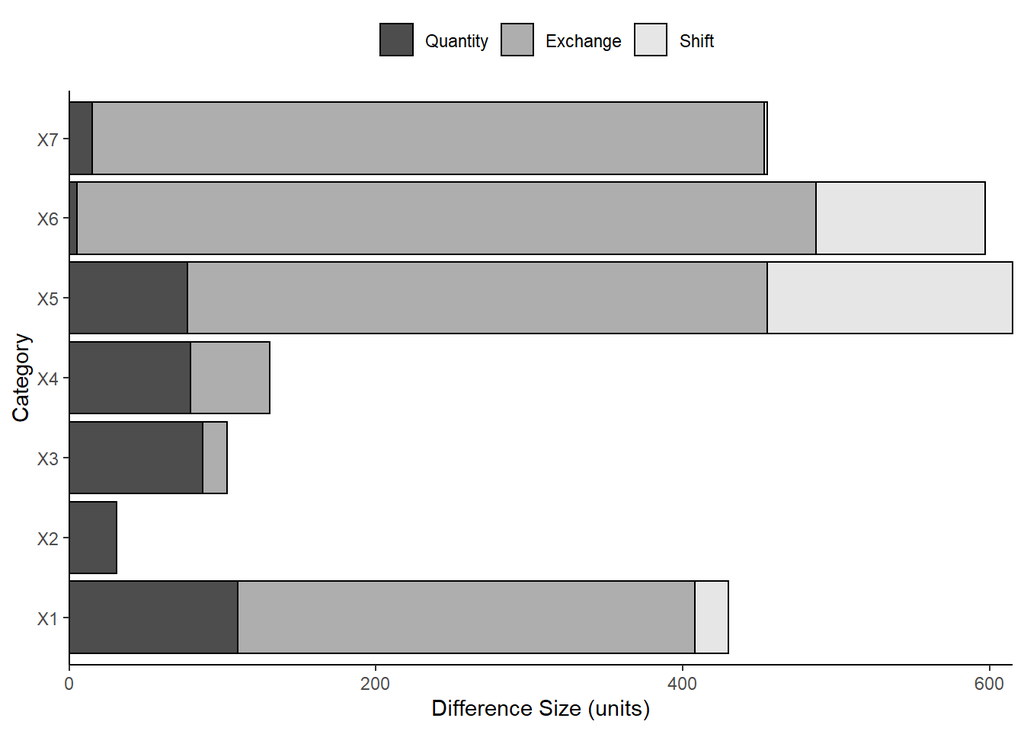

```r
categoryComponentsPlot (ctmatrix=Confusion2)
```

We can then calculate exchange and overall difference metrics

```r
exchangeDij(Confusion2)
```

```
##    X1 X2 X3 X4 X5  X6 X7
## 1   0  0  0  0  0   0  0
## 2   0  0  0  0  0   0  0
## 3   0  0  0  0  0   0  0
## 4   0  0  0  0  0   0  0
## 5 298  0  0 52  0   0  0
## 6   0  0 16  0 28   0  0
## 7   0  0  0  0  0 438  0
```

```r
exchangeDj(Confusion2)
```

```
##   1   2   3   4   5   6   7
## 298   0  16  52 378 482 438
```

```r
overallAllocD(Confusion2)
```

```
## [1] 979
```

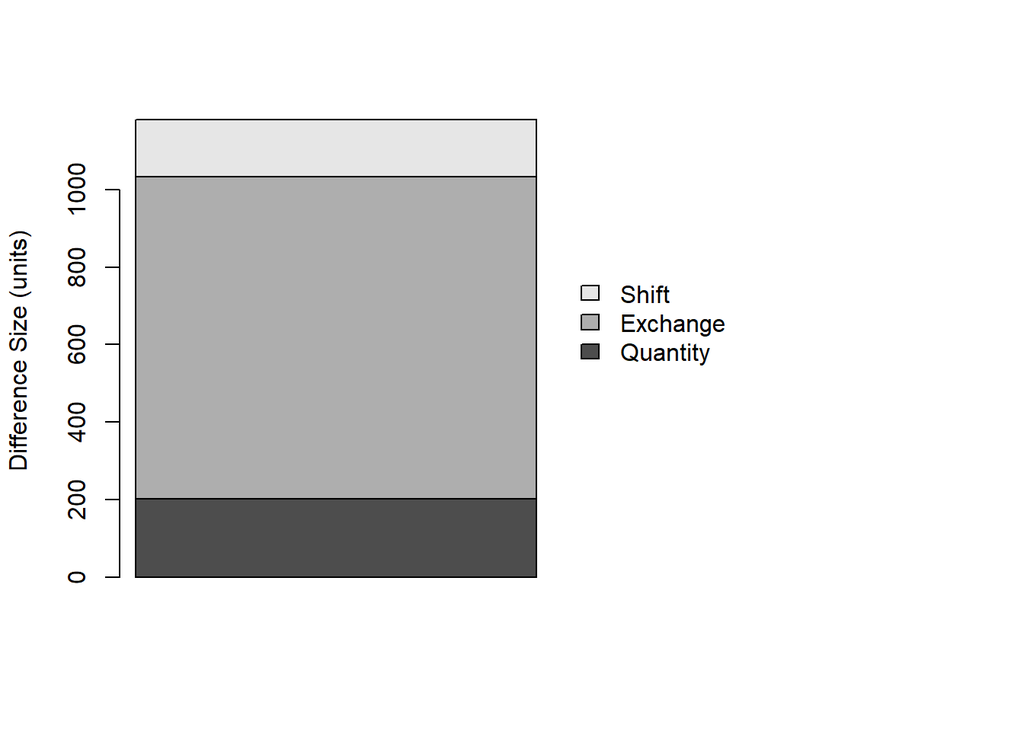

```r
overallComponentsPlot(ctmatrix=Confusion2)
```

```r
overallDiff(Confusion2)
```

```
## [1] 1181
```

```r
overallDiffCatj(Confusion2)
```

```
##   1   2   3   4   5   6   7
## 430  31 103 131 615 597 455
```

```r
overallExchangeD(Confusion2)
```

```
## [1] 832
```

```r
overallQtyD(Confusion2)
```

```
## [1] 202
```

```r
overallShiftD(Confusion2)
```

```
## [1] 147
```

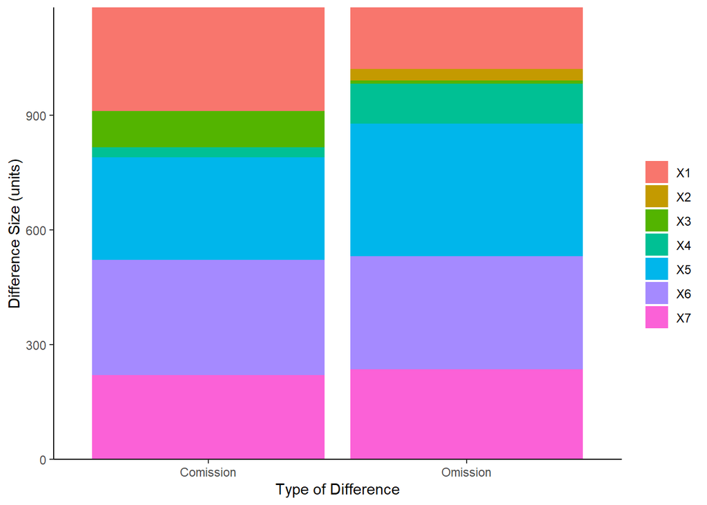

```r
overallSourcesPlot(ctmatrix=Confusion2)
```

```r
quantityDj(Confusion2)
```

```
##   1   2   3   4   5   6   7
## 110  31  87  79  77   5  15
```

We can then calculate shift difference at the category level from a contingency table derived from the crosstabulation between comparison variable and reference variable. Shift refers to the difference remaining after subtracting quantity difference and exchange from the overall difference

```r
shiftDj(Confusion2)
```

```
##   1   2   3   4   5   6   7
##  22   0   0   0 160 110   2
```

And then produce a stacked bar plot showing the ommission and commission components for each category

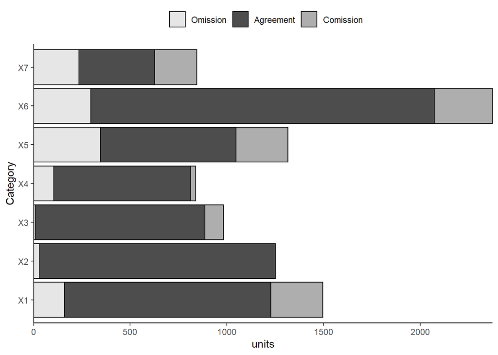

```r
categorySourcesPlot(ctmatrix=Confusion2)
```